# GOM Contaminated Sediments analysis: data tidying

Joshua Harkness and Autumn Pauly, 2023-10-20

# Introduction

This document is tidying the data sets of a series of reports published by the U.S. Geological Survey about the distributions and concentrations of contaminated sediments in the Gulf of Maine.

## Load packages

These are the packages that will be needed to tidy data frames.

```r
library(tidyverse)
library(readxl)
library(sf)
library(visdat)
library(naniar)
```

##Load full datasets These data sets are very large. Since these are all very large data files, we will select useful variables and variables we are interested in looking at to pare them down to a more manageable size.

```r
stations_full = read_xls("/cloud/project/data/original_datasets/STAT2002.xls", sheet = 2, skip = 3)
PCBs_full = read_excel("/cloud/project/data/original_datasets/PCBP2002.xls", sheet = 2, skip = 3)
PAHs_full = read_excel("/cloud/project/data/original_datasets/PAHS2002.xls", sheet = 2, skip = 3)
organics_full = read_excel("/cloud/project/data/original_datasets/GENO2002.xls", sheet = 2, skip = 3)
```

#Selecting variables ###PCBs Creates PCBs2002 data frame. These are variables of interest, principally contaminant concentration with assigned unique IDs that can be associated to unique IDs in the other data frames.

```r
PCBs2002 = select(PCBs_full, c(UNIQUE_ID, PCB_52_NGG, PCB101_NGG, PCB118_NGG, PCB128_NGG, PCB138_NGG, PCB153_NGG, PCB180_NGG, PCB206_NGG, PCB209_NGG, DDT_4_4_C, DDT_2_4_C, DDE_4_4_C, DDD_4_4_C, ENDRIN_C, ENDR_ALD_C, ALDRIN_C, DIELDRN_C, CLRDNE_T_C, MIREX_C, METHOXYCLC, BHC_A_C, BHC_B_C, BHC_D_C, LINDANE_C))
```

###Stations Creates Stations2002 data frame. These are unique IDs, coordinates (Lat/Lon in decimal degrees), depth sounding (meters), state name, USGS quad name, general and specific location names, area code, sampling date, resampling date, and information on sediment collection.

```r
Station2002 = select(stations_full, c(UNIQUE_ID, LATITUDE, LONGITUDE, SOUNDING_M, STATE_NAME, QUAD_NAME, GEN_LOC_NM, SPECFC_LOC, AREA_CODE, SAMP_DATE1, TO_SMP_DT2, DPTH_N_COR, DPTH_CODE, COR_GRB_CD))
```

###Organics Creates Organics2002 dataframe with selected variables of interest. These include general organics as well as total PCB and some notable pesticide concentrations.

```r
Organics2002 = select(organics_full, c(UNIQUE_ID, REPNO_ORG, TOTREP_ORG, TVS_EP_PCT, O_G_PCT, O_G_UGG, PHCTOT_PCT, PHCTOT_UGG, PCB_T_UGG, DDT_T_NGG, DDE_T_NGG, DDD_T_NGG, PEST_UG_G, PAHTOT_PCT, PAHTOT_UGG, LIPIDS_NGG, CLOST_SP_G, MBT_C, DBT_C, TBT_C, TTBT_C))
```

###PAHs Creates PAHs2002 dataframe with selected variables of interest. These are principally contaminate concentrations with unique IDs associated with other data frames.

```r
PAHs2002 = select(PAHs_full, c("UNIQUE ID", BENZNE_C, "2BZTPN_C", "2BZTPN_T_C", C1DIBZTPNC, C2DIBZTPNC, C3DIBZTPNC, "2BZFRN_T_C", NAPHTHLN_C, NPHTLN_T_C, C1NPHTLN_C, "1MTYLNAP_C", "2MTYLNAP_C", C2NPHTLN_C, C3NPHTLN_C, C4NPHTLN_C, BIPHENYL_C, ACNPHTHN_C, ACNPHTYL_C, FLUORENE_C, C1FLORNE_C, C2FLORNE_C, C3FLORNE_C, PHNANTHR_C, "1MT_PHE_C", C2PHNANT_C, C3PHNANT_C, C4PHNANT_C, ANTHRACN_C, BZ_A_ANT_C, "2_AH_ANT_C", PYRENE_C, C1PYRENE_C, BZ_A_PYR_C, BZ_E_PYR_C, IN_123_PYC, "3_4BNZPY_C", FLORNTHN_C, C1FLRNTHNC, BZ_B_FLUOC, BZ_K_FLUOC, CHRYSENE_C, CHRYS_C1_C, CHRYS_C2_C, CHRYS_C3_C, CHRYS_C4_C, PERYLENE_C, BNZ_G_PYLC, B_GHI_PYLC))

colnames(PAHs2002)[1] ="UNIQUE_ID"
```

## Recoding/combining Categories in Stations Data Set

### Renaming Specific Locations

```r
Station2002 <- Station2002 %>%
  mutate(site = fct_recode(SPECFC_LOC,
                           "Chelsea River" = "Upper Chelsea River",
                           "Chelsea River" = "Lower Chelsea River",
                           "Chelsea River" = "Chelsea River mouth",
                           "Chelsea River" = "Chelsea River A",
                           "Chelsea River" = "Chelsea River B",
                           "Chelsea River" = "Chelsea River C",
                           "Chelsea River" = "Chelsea River D",
                           "Chelsea River" = "Chelsea River E",
                           "Chelsea River" = "Chelsea River F",
                           "Chelsea River" = "Chelsea River G",
                           "Chelsea River" = "Chelsea River H",
                           "Chelsea River" = "Chelsea River, Gulf Oil Fuel Off-Loading Pier",
                           "Chelsea River" = "Chelsea River, Golf Oil Fuel Off-Loading Pier",
                           "Mystic River" = "MYSTIC RIVER",
                           "Mystic River" = 'Mystic River "B"',
                           "Mystic River" = 'Mystic "A"-7830',
                           "Mystic River" = 'Mystic "B"-7831',
                           "Chelsea River" = 'Chelsea "A"-7828',
                           "Chelsea River" = 'Chelsea "E"-7829',
                           "Island End River" = "ISLAND END RIVER",
                           "Weymouth Fore River" = "FORE RIVER",
                           "Fore River" = "Portland Fore River",
                           "Fore River" = "Portland Harbor & Fore River",
                           "Saco River" = "Saco River & Camp Ellis Harbor",
                           "Kennebec River" = "Kennebec River to Bath",
                           "Kennebec River" =   "KENNEBEC RIVER",
                           "Kennebec River" = "KENNEBEC RIVER,ME.",
                           "Penobscot River" = "PENOBSCOT RIVER",
                           "Penobscot River" = "MOUTH PENOBSCOT RIVER",
                           "Penobscot River" = "Penobscot River To Bangor"
                           ))
```

### Renaming General Locations

```r
Station2002 <- Station2002 %>%
mutate(GEN_LOC_NM = fct_recode(GEN_LOC_NM,
                           "Rockland to north" = "North of 44; to 50M isobath",
                           "Cape Elizabeth to Rockland" = "43.5N to 44N; to 50M isobath",
                           "Cape Ann to Cape Elizabeth" = "CAPE ANN to 43.5N",
                           "Boston Inner Harbor" = "BOSTON INNER HARBOR",
                           "Cape Code Bay" = "CAPE COD BAY",
                           "Gulf of Maine (>50m Isobath)" = "GULF OF MAINE, >50M ISOBATH",
                           "Northwest Boston Harbor" = "NORTHWEST BOSTON HARBOR",
                           "Southeast Boston Harbor" = "SOUTHEAST BOSTON HARBOR",
                           "Gulf of Maine (<=50m Isobath)" = "GULF OF MAINE, <=50M",
                           "Central Boston Harbor" = "CENTRAL BOSTON HARBOR",
                           "Inland/Rivers" = "INLAND / RIVERS",
                           "Harbor Approaches" = "HARBOR APPROACHES",
                           "Massachusetts Bays" = "MASS BAYS"))
```

[output not shown]

## Modifying Dataframes

### Joining Stations with Contaminent Data Sets

This action associates location information and contaminant data by each sample’s `UNIQUE_ID`.

```r
  PCBs_loc <- full_join(Station2002, PCBs2002, by = "UNIQUE_ID")

  PAHs_loc <- full_join(Station2002, PAHs2002, by = "UNIQUE_ID")

  Organics_loc <- full_join(Station2002, Organics2002, by = "UNIQUE_ID")
```

###Recoding PAHs’ Special Character Values as Numeric The amount values for the PAH containment `CHRYSENE_C` needs to be recoded from character values to numeric values.

```r
  PAHs_loc <- PAHs_loc %>%
    mutate(CHRYSENE_C = recode(CHRYSENE_C, ">" = "NA"))

  PAHs_loc %>%
    transform(PAHs_loc, CHRYSENE_C = as.numeric(CHRYSENE_C))
```

[output not shown]

[output cut: 25397 more lines]

# Visualizing Missing Data

Visualizing missing data can help us determine which specific contaminants were actually detected, and should then be analyzed, as there are a lot of missing values within each data set.

###Missing PCB Data

```r
#Visualizing the percentage of missing data
#visdat::vis_miss(PCBs_loc)

#visualizing correlations in data as a heatmap - only numeric values...
#dplyr::select(PCBs_loc, where(is.numeric)) %>%
#visdat::vis_cor(PCBs_loc, "pearson", "pairwise.complete.obs", facet)

#we should highlight the locations where there are PCBs detected
```

```r
 visdat::vis_dat(PCBs_loc)
```

[figure not shown]

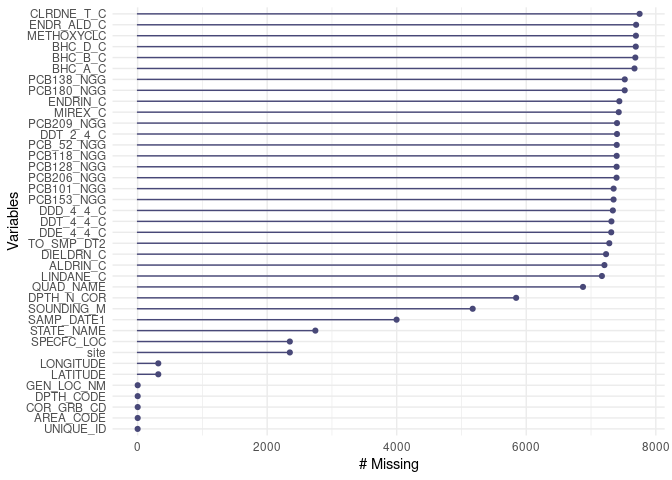

```r
naniar::gg_miss_var(PCBs_loc)
```

```r
naniar::miss_var_summary(PCBs_loc)
```

```
## # A tibble: 39 × 3
##    variable   n_miss pct_miss
##    <chr>       <int>    <dbl>
##  1 CLRDNE_T_C   7750     98.8
##  2 ENDR_ALD_C   7696     98.1
##  3 METHOXYCLC   7693     98.0
##  4 BHC_D_C      7691     98.0
##  5 BHC_B_C      7684     97.9
##  6 BHC_A_C      7671     97.7
##  7 PCB138_NGG   7521     95.8
##  8 PCB180_NGG   7520     95.8
##  9 ENDRIN_C     7437     94.8
## 10 MIREX_C      7428     94.6
## # ℹ 29 more rows
```

###Missing PAH Data

```r
#Visualizing the percentage of missing data
#visdat::vis_miss(PAHs_loc)

#visualizing correlations in data as a heatmap - only numeric values...
#dplyr::select(PAHs_loc, where(is.numeric)) %>%
#visdat::vis_cor(PAHs_loc, "pearson", "pairwise.complete.obs", facet)

#we should highlight the locations where there are PAHs detected
```

###Missing Organics Data

```r
#Visualizing the percentage of missing data
# visdat::vis_miss(Organics_loc)

#visualizing correlations in data as a heatmap - only numeric values...
#dplyr::select(Organics_loc, where(is.numeric)) %>%
#visdat::vis_cor(Organics_loc, "pearson", "pairwise.complete.obs", facet)

#This shows us in which station specific organics are found
```

# Loading full datasets as CSVs

```r
#write_csv(organics_full, "/cloud/project/data/datasets_csv/organics_full.csv")
#write_csv(PAHs_full, "/cloud/project/data/datasets_csv/PAHs_full.csv")
#write_csv(PCBs_full, "/cloud/project/data/datasets_csv/PCBs_full.csv")
#write_csv(stations_full, "/cloud/project/data/datasets_csv/stations_full.csv")
```

# JH – do we need to write full .csv files? These are the same as the excel files, just diff format

# Write loc datasets as CSVs

```r
#write_csv(Organics_loc, "/cloud/project/data/datasets_csv/Organics_loc.csv")
#write_csv(PAHs_loc, "/cloud/project/data/datasets_csv/PAHs_loc.csv")
#write_csv(PCBs_loc, "/cloud/project/data/datasets_csv/PCBs_loc.csv")
```

# JH – we do not need to load .shp files here; we still have to load them separately whenever we use them.